# sparklyr

Joseph Rickert

10/30/2017

This notebook describes how R users can access Spark and make use of Spark resources through the [`sparklyr`](https://CRAN.R-project.org/package=sparklyr) package, which allows users to connect to [`Spark`](http://spark.apache.org/) from R.

The example presented is adapted from the [Online Documentation](https://spark.rstudio.com).

[figure not shown]

With `sparklyr` R users can: * Use `deply` functions to access `Spark` * Filter and aggregate `Spark` datasets and them bring them into R for analysis and visualization  
* Use `Spark's` distributed machine learning library [MLlib](http://spark.apache.org/docs/latest/mllib-guide.html)  
* Create [extensions](https://spark.rstudio.com/extensions.html) that call the full `Spark` API and provide interfaces to `Spark` packages

Another way to think of things is that `sparklyr` allows `Spark` to act as a backend for `dplyr` and other R packages and become part of the data science workflow in R.

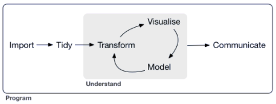

### Preliminaries

In this section we install the `sparklyr` package and then use the function `sparklyr::spark_install()` to install a local copy of `Spark`.

```r
install.packages("sparklyr")
library(sparklyr)
spark_install(version = "2.1.0")
```

### Connecting to Spark

There are two ways to use `sparklyr` with `Spark`. We call these two **deployment** modes:  
* Local - running `Spark` locally on the desktop  
* Cluster - working directly within or alongside a Spark cluster ([standalone](http://spark.apache.org/docs/latest/spark-standalone.html), [YARN](http://hadoop.apache.org/docs/current/hadoop-yarn/hadoop-yarn-site/YARN.html), [Mesos](http://mesos.apache.org/), etc.)

For this example we will use a local connection which we can affect either using the function `sparklyr::spark_connect()` or using the Connection window in the RStudio IDE. For information on making cluster connections see the [Deployment and Configuration](https://spark.rstudio.com/articles/deployment-overview.html) overview.

```r
library(sparklyr)
sc <- spark_connect(master = "local")
```

### Moving Data into Spark

We begin by copying the some data sets into `Spark`. We will use the `nycflights13` data which we have used before, the `Lahman` dataset containing baseball stats, and good old `iris`.

```r
install.packages(c("nycflights13", "Lahman"))
```

```r
library(dplyr)
library(nycflights13)
library(Lahman)
iris_tbl <- copy_to(sc, iris)
flights_tbl <- copy_to(sc, nycflights13::flights, "flights")
batting_tbl <- copy_to(sc, Lahman::Batting, "batting")
```

Now, we check to see what tables we have in Spark. Notice that the tables also show up in the RStudio IDE Connection pane.

```r
src_tbls(sc)
```

```
## [1] "batting" "flights" "iris"
```

### Using `dplyr` with data in `Spark`

In this first example, we use `dplyr::filter()` to fetch flights with two minute departure delays.

```r
# filter by departure delay and print the first few records
flights_tbl %>% filter(dep_delay == 2)
```

```
## # Source:   lazy query [?? x 19]
## # Database: spark_connection
##     year month   day dep_time sched_dep_time dep_delay arr_time
##    <int> <int> <int>    <int>          <int>     <dbl>    <int>
##  1  2013     1     1      517            515         2      830
##  2  2013     1     1      542            540         2      923
##  3  2013     1     1      702            700         2     1058
##  4  2013     1     1      715            713         2      911
##  5  2013     1     1      752            750         2     1025
##  6  2013     1     1      917            915         2     1206
##  7  2013     1     1      932            930         2     1219
##  8  2013     1     1     1028           1026         2     1350
##  9  2013     1     1     1042           1040         2     1325
## 10  2013     1     1     1231           1229         2     1523
## # ... with more rows, and 12 more variables: sched_arr_time <int>,
## #   arr_delay <dbl>, carrier <chr>, flight <int>, tailnum <chr>,
## #   origin <chr>, dest <chr>, air_time <dbl>, distance <dbl>, hour <dbl>,
## #   minute <dbl>, time_hour <dbl>
```

Here, we compute mean distance and mean arrival delay for flights with more than observations and distances less than 2,000 miles.

```r
delay <- flights_tbl %>%
  group_by(tailnum) %>%
  summarise(count = n(), dist = mean(distance), delay = mean(arr_delay)) %>%
  filter(count > 20, dist < 2000, !is.na(delay)) %>%
  collect
```

Then, we plot that information.

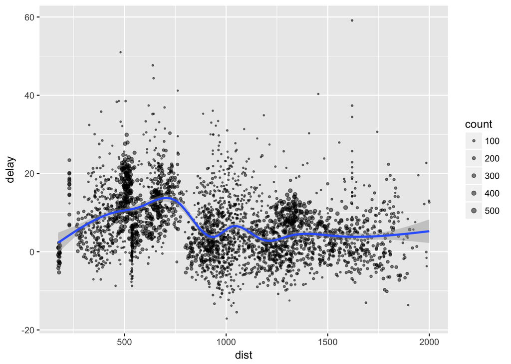

```r
# plot delays
library(ggplot2)
ggplot(delay, aes(dist, delay)) +
  geom_point(aes(size = count), alpha = 1/2) +
  geom_smooth() +
  scale_size_area(max_size = 2)
```

In a slightly more elaborate example, we show a typical dplyr workflow using the baseball data.

```r
batting_tbl
```

```
## # Source:   table<batting> [?? x 22]
## # Database: spark_connection
##     playerID yearID stint teamID  lgID     G    AB     R     H   X2B   X3B
##        <chr>  <int> <int>  <chr> <chr> <int> <int> <int> <int> <int> <int>
##  1 abercda01   1871     1    TRO    NA     1     4     0     0     0     0
##  2  addybo01   1871     1    RC1    NA    25   118    30    32     6     0
##  3 allisar01   1871     1    CL1    NA    29   137    28    40     4     5
##  4 allisdo01   1871     1    WS3    NA    27   133    28    44    10     2
##  5 ansonca01   1871     1    RC1    NA    25   120    29    39    11     3
##  6 armstbo01   1871     1    FW1    NA    12    49     9    11     2     1
##  7 barkeal01   1871     1    RC1    NA     1     4     0     1     0     0
##  8 barnero01   1871     1    BS1    NA    31   157    66    63    10     9
##  9 barrebi01   1871     1    FW1    NA     1     5     1     1     1     0
## 10 barrofr01   1871     1    BS1    NA    18    86    13    13     2     1
## # ... with more rows, and 11 more variables: HR <int>, RBI <int>,
## #   SB <int>, CS <int>, BB <int>, SO <int>, IBB <int>, HBP <int>,
## #   SH <int>, SF <int>, GIDP <int>
```

We select some of the columns of from `batting-tbl` sort by player, year and team, group by players then rank the data by hits and select the top two years for each player in which he had at least one hit.

```r
batting_tbl %>%
  select(playerID, yearID, teamID, G, AB:H) %>%
  arrange(playerID, yearID, teamID) %>%
  group_by(playerID) %>%
  filter(min_rank(desc(H)) <= 2 & H > 0)
```

```
## # Source:     lazy query [?? x 7]
## # Database:   spark_connection
## # Groups:     playerID
## # Ordered by: playerID, yearID, teamID
##     playerID yearID teamID     G    AB     R     H
##        <chr>  <int>  <chr> <int> <int> <int> <int>
##  1 aaronha01   1959    ML1   154   629   116   223
##  2 aaronha01   1963    ML1   161   631   121   201
##  3  abadfe01   2012    HOU    37     7     0     1
##  4 abbated01   1905    BSN   153   610    70   170
##  5 abbated01   1904    BSN   154   579    76   148
##  6 abbeych01   1894    WAS   129   523    95   164
##  7 abbeych01   1895    WAS   132   511   102   141
##  8 abbotji01   1999    MIL    20    21     0     2
##  9 abnersh01   1992    CHA    97   208    21    58
## 10 abnersh01   1990    SDN    91   184    17    45
## # ... with more rows
```

### Using SQL

We can also use SQL queries to interrogate tables in a `Spark` cluster. The `spark_connection` object implements a DBI interface for Spark. We can use `dbGetQuery` to execute SQL and return the result as an R data frame. We could have used a SQL query to look at just the first 10 rows of the baseball data set.

```r
library(DBI)
batting_preview <- dbGetQuery(sc, "SELECT * FROM batting LIMIT 10")
batting_preview
```

```
##     playerID yearID stint teamID lgID  G  AB  R  H X2B X3B HR RBI SB CS BB
## 1  abercda01   1871     1    TRO   NA  1   4  0  0   0   0  0   0  0  0  0
## 2   addybo01   1871     1    RC1   NA 25 118 30 32   6   0  0  13  8  1  4
## 3  allisar01   1871     1    CL1   NA 29 137 28 40   4   5  0  19  3  1  2
## 4  allisdo01   1871     1    WS3   NA 27 133 28 44  10   2  2  27  1  1  0
## 5  ansonca01   1871     1    RC1   NA 25 120 29 39  11   3  0  16  6  2  2
## 6  armstbo01   1871     1    FW1   NA 12  49  9 11   2   1  0   5  0  1  0
## 7  barkeal01   1871     1    RC1   NA  1   4  0  1   0   0  0   2  0  0  1
## 8  barnero01   1871     1    BS1   NA 31 157 66 63  10   9  0  34 11  6 13
## 9  barrebi01   1871     1    FW1   NA  1   5  1  1   1   0  0   1  0  0  0
## 10 barrofr01   1871     1    BS1   NA 18  86 13 13   2   1  0  11  1  0  0
##    SO IBB HBP SH SF GIDP
## 1   0  NA  NA NA NA   NA
## 2   0  NA  NA NA NA   NA
## 3   5  NA  NA NA NA   NA
## 4   2  NA  NA NA NA   NA
## 5   1  NA  NA NA NA   NA
## 6   1  NA  NA NA NA   NA
## 7   0  NA  NA NA NA   NA
## 8   1  NA  NA NA NA   NA
## 9   0  NA  NA NA NA   NA
## 10  0  NA  NA NA NA   NA
```

Finally, we disconnect from `Spark`.

```r
spark_disconnect(sc)
```

### More Information

For more information, have a look at: the [Gallery] (https://spark.rstudio.com/articles/gallery.html) of `sparklyr` examples, the [Online Documentation](https://spark.rstudio.com) for `sparklyr` and the Documentation for using `sparklyr` with Apache Spark Cluster.

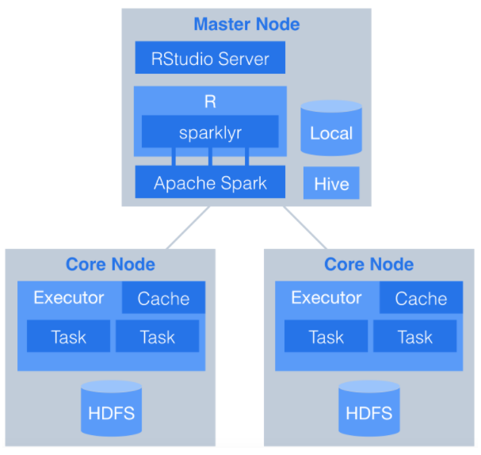